# Food_Hub_Project_zoeenjanjua

```python
# import libraries for data manipulation
import numpy as np
import pandas as pd

# import libraries for data visualization
import matplotlib.pyplot as plt
import seaborn as sns

#import library for statistical calculations
import scipy.stats as stats
```

```python
# read the data
df = pd.read_csv('foodhub_order.csv')
# returns the first 5 rows
df.head()
```

|  | order_id | customer_id | restaurant_name | cuisine_type | cost_of_the_order | day_of_the_week | rating | food_preparation_time | delivery_time |
| --- | --- | --- | --- | --- | --- | --- | --- | --- | --- |
| 0 | 1477147 | 337525 | Hangawi | Korean | 30.75 | Weekend | Not given | 25 | 20 |
| 1 | 1477685 | 358141 | Blue Ribbon Sushi Izakaya | Japanese | 12.08 | Weekend | Not given | 25 | 23 |
| 2 | 1477070 | 66393 | Cafe Habana | Mexican | 12.23 | Weekday | 5 | 23 | 28 |
| 3 | 1477334 | 106968 | Blue Ribbon Fried Chicken | American | 29.20 | Weekend | 3 | 25 | 15 |
| 4 | 1478249 | 76942 | Dirty Bird to Go | American | 11.59 | Weekday | 4 | 25 | 24 |

**Question 1: How many rows and columns are present in the data? [0.5 mark]**

```python
# Write a code to calculate store number of rows
rows= len(df.index)
# Write a code to calculate and store number of columns
cols= df.shape[1]
print("Number of Rows:", rows)
print("Number of Columns:", cols)
```

```
Number of Rows: 1898
Number of Columns: 9
```

**Question 2: What are the datatypes of the different columns in the dataset? (The info() function can be used) [0.5 mark]**

```python
# Use info() to print a concise summary of the DataFrame
df.info()
```

```
<class 'pandas.core.frame.DataFrame'>
RangeIndex: 1898 entries, 0 to 1897
Data columns (total 9 columns):
 #   Column                 Non-Null Count  Dtype
---  ------                 --------------  -----
 0   order_id               1898 non-null   int64
 1   customer_id            1898 non-null   int64
 2   restaurant_name        1898 non-null   object
 3   cuisine_type           1898 non-null   object
 4   cost_of_the_order      1898 non-null   float64
 5   day_of_the_week        1898 non-null   object
 6   rating                 1898 non-null   object
 7   food_preparation_time  1898 non-null   int64
 8   delivery_time          1898 non-null   int64
dtypes: float64(1), int64(4), object(4)
memory usage: 133.6+ KB
```

**Question 3: Are there any missing values in the data? If yes, treat them using an appropriate method. [1 mark]**

```python
#Detect and treat missing data
df.isnull()
```

|  | order_id | customer_id | restaurant_name | cuisine_type | cost_of_the_order | day_of_the_week | rating | food_preparation_time | delivery_time |
| --- | --- | --- | --- | --- | --- | --- | --- | --- | --- |
| 0 | False | False | False | False | False | False | False | False | False |
| 1 | False | False | False | False | False | False | False | False | False |
| 2 | False | False | False | False | False | False | False | False | False |
| 3 | False | False | False | False | False | False | False | False | False |
| 4 | False | False | False | False | False | False | False | False | False |
| ... | ... | ... | ... | ... | ... | ... | ... | ... | ... |
| 1893 | False | False | False | False | False | False | False | False | False |
| 1894 | False | False | False | False | False | False | False | False | False |
| 1895 | False | False | False | False | False | False | False | False | False |
| 1896 | False | False | False | False | False | False | False | False | False |
| 1897 | False | False | False | False | False | False | False | False | False |

1898 rows × 9 columns

*Conclusion: There is no missing data in the above code*

(This was also previously obsered since the information showed no null count)

**Question 4: Check the statistical summary of the data. What is the minimum, average, and maximum time it takes for food to be prepared once an order is placed? [2 marks]**

```python
#Prirnt the minimum time it takes for the food to be prepared
df[['food_preparation_time']].min()
```

```
food_preparation_time    20
dtype: int64
```

```python
#Prirnt the maximum time it takes for the food to be prepared
df[['food_preparation_time']].max()
```

```
food_preparation_time    35
dtype: int64
```

```python
#Print the average time it takes for the food to be prepared
df[['food_preparation_time']].mean()
```

```
food_preparation_time    27.37197
dtype: float64
```

**Question 5: How many orders are not rated? [1 mark]**

```python
#Count the total amount of unrated orders
df["rating"].value_counts().get("Not given", 0)
```

```
736
```

**Question 6: Explore all the variables and provide observations on their distributions. (Generally, histograms, boxplots, countplots, etc. are used for univariate exploration.) [9 marks]**

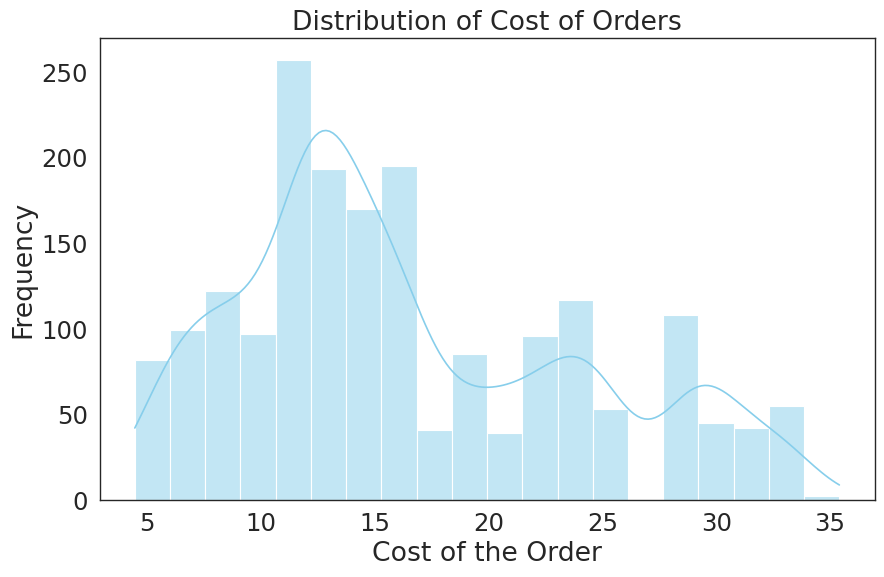

```python
# Histogram for cost_of_the_order
plt.figure(figsize=(10, 6))
sns.histplot(df['cost_of_the_order'], bins=20, kde=True, color='skyblue')
plt.title('Distribution of Cost of Orders')
plt.xlabel('Cost of the Order')
plt.ylabel('Frequency')
plt.show()
```

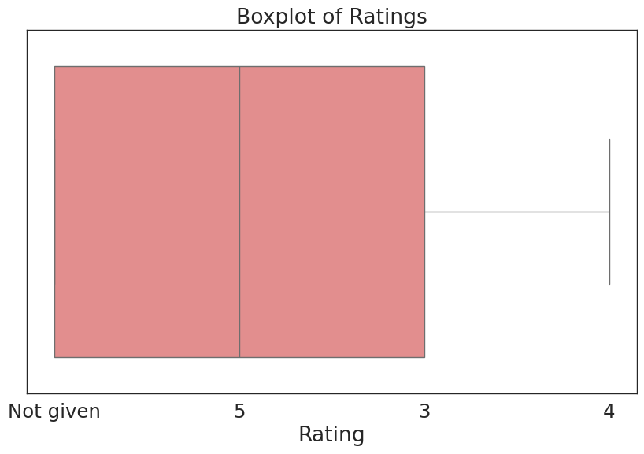

```python
# Boxplot for rating
plt.figure(figsize=(10, 6))
sns.boxplot(x='rating', data=df, color='lightcoral')
plt.title('Boxplot of Ratings')
plt.xlabel('Rating')
plt.show()
```

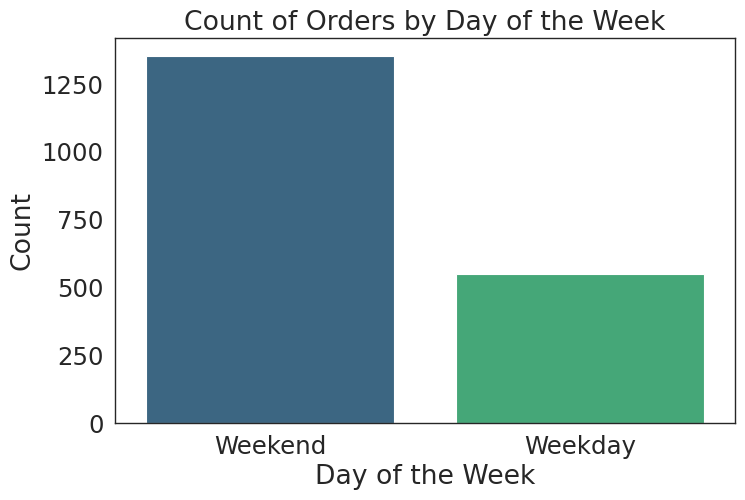

```python
# Countplot for day_of_the_week
plt.figure(figsize=(8, 5))
sns.countplot(x='day_of_the_week', data=df, hue='day_of_the_week', palette='viridis', legend=False)
plt.title('Count of Orders by Day of the Week')
plt.xlabel('Day of the Week')
plt.ylabel('Count')
plt.show()
```

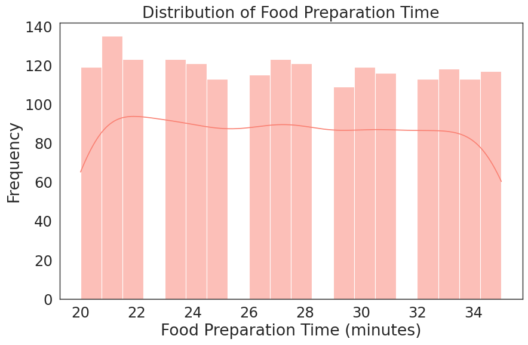

```python
# Histogram for food_preparation_time
plt.figure(figsize=(10, 6))
sns.histplot(df['food_preparation_time'], bins=20, kde=True, color='salmon')
plt.title('Distribution of Food Preparation Time')
plt.xlabel('Food Preparation Time (minutes)')
plt.ylabel('Frequency')
plt.show()
```

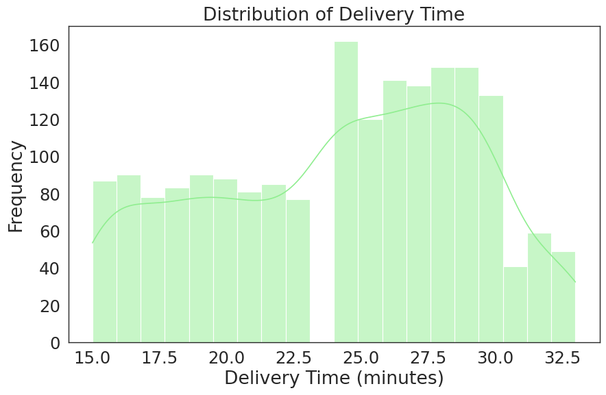

```python
# Histogram for delivery_time
plt.figure(figsize=(10, 6))
sns.histplot(df['delivery_time'], bins=20, kde=True, color='lightgreen')
plt.title('Distribution of Delivery Time')
plt.xlabel('Delivery Time (minutes)')
plt.ylabel('Frequency')
plt.show()
```

**Question 7: Which are the top 5 restaurants in terms of the number of orders received? [1 mark]**

```python
#Count the top 5 restaurants
df["restaurant_name"].value_counts().get("Not given", 0)
```

```
0
```

```python
#Count the Top 5 most ordered from Restaurants
import collections
top_5 = collections.Counter(df["restaurant_name"]).most_common(5)
print(top_5)
```

```
[('Shake Shack', 219), ('The Meatball Shop', 132), ('Blue Ribbon Sushi', 119), ('Blue Ribbon Fried Chicken', 96), ('Parm', 68)]
```

**Question 8: Which is the most popular cuisine on weekends? [1 mark]**

```python
#Filter the days to only weekends
weekends = df[df["day_of_the_week"] == "Weekend"]

#Calculate the count
cuisine_counts = weekends.groupby('cuisine_type').size().sort_values(ascending=False)

#Get the most popular cuisine on Weekends
most_popular_cuisine = cuisine_counts.index[0]

print(f"The Most Popular Cuisine on Weekends is: {most_popular_cuisine}")
```

```
The Most Popular Cuisine on Weekends is: American
```

**Question 9: What percentage of the orders cost more than 20 dollars? [2 marks]**

```python
# Calculate percentage of cost more than $20
cost_of_the_order = df["cost_of_the_order"]
More = 0

# Use the gt() method to compare each element with 20.00
more_than_20 = cost_of_the_order.gt(20.00)

# Sum the boolean Series to get the number of elements greater than 20.00
More = more_than_20.sum()
percenet_more = 0
percent_more = (More/1898)*100
print(percent_more,"percent of the cost are more than $20")
```

```
29.24130663856691 percent of the cost are more than $20
```

**Question 10: What is the mean order delivery time? [1 mark]**

```python
#Print the mean time it takes for order delivery
df[['delivery_time']].mean()
```

```
delivery_time    24.161749
dtype: float64
```

**Question 11: The company has decided to give 20% discount vouchers to the top 3 most frequent customers. Find the IDs of these customers and the number of orders they placed. [1 mark]**

```python
# Calculate the frequency of orders for each customer
customer_frequency = df.groupby('customer_id')['order_id'].count().sort_values(ascending=False)

# Select the top 3 most frequent customers
top_3_customers = customer_frequency.head(3)

# Get the IDs and order counts of the top 3 customers
top_3_customer_ids = top_3_customers.index.to_list()
top_3_customer_orders = top_3_customers.values.tolist()

# Print the results
print("Top 3 Most Frequent Customers:")
for i in range(3):
  print(f"{i+1}. Customer ID: {top_3_customer_ids[i]}, Orders: {top_3_customer_orders[i]}")

# Give 20% discount vouchers to the top 3 customers
# (This part is not included in the code, as it requires additional information about the discount process)
```

```
Top 3 Most Frequent Customers:
1. Customer ID: 52832, Orders: 13
2. Customer ID: 47440, Orders: 10
3. Customer ID: 83287, Orders: 9
```

**Question 12: Perform a multivariate analysis to explore relationships between the important variables in the dataset. (It is a good idea to explore relations between numerical variables as well as relations between numerical and categorical variables) [10 marks]**

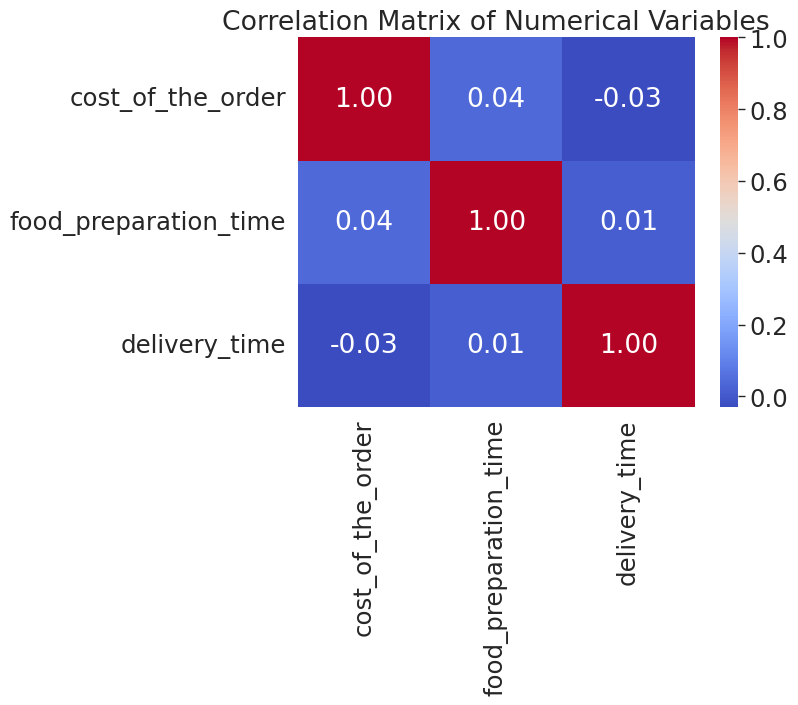

```python
# Correlation between the numeric values
numerical_vars = df[['cost_of_the_order', 'rating', 'food_preparation_time', 'delivery_time']]
correlation_matrix = numerical_vars.corr(numeric_only=True)

# Plotting the heatmap
sns.heatmap(correlation_matrix, annot=True, cmap="coolwarm", fmt=".2f")
plt.title("Correlation Matrix of Numerical Variables")
plt.show()
```

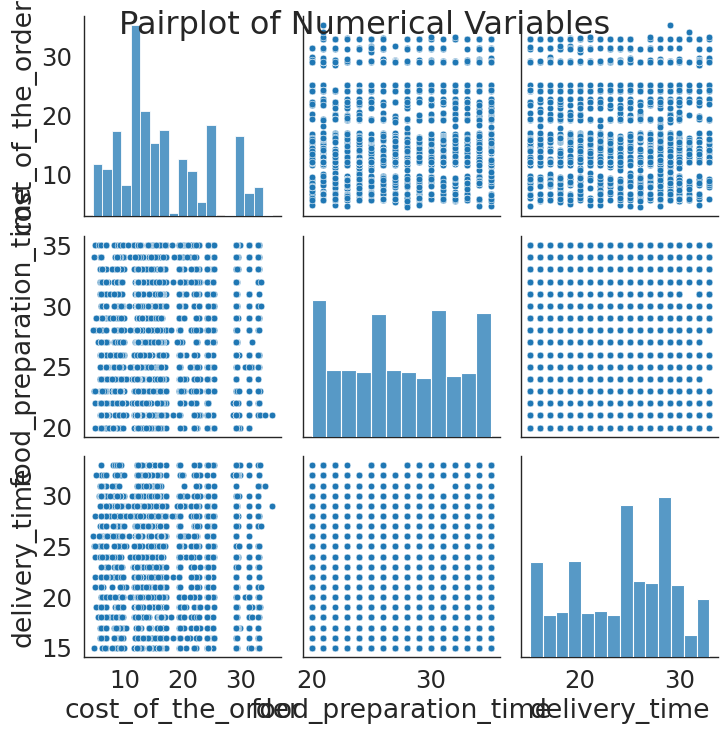

```python
#Create a Pairplot to visualize the relationships between the numeric values
sns.pairplot(numerical_vars)
plt.suptitle("Pairplot of Numerical Variables")
plt.show()
```

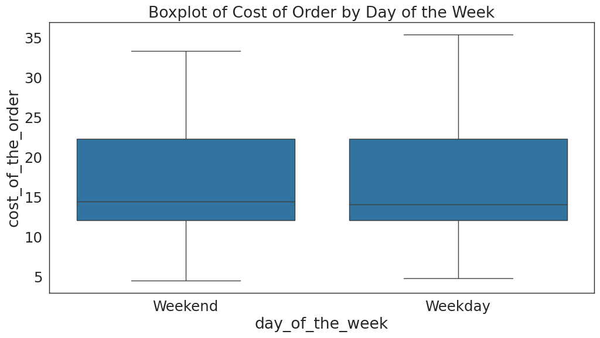

```python
#Create box plots
plt.figure(figsize=(12, 6))
sns.boxplot(x='day_of_the_week', y='cost_of_the_order', data=df)
plt.title("Boxplot of Cost of Order by Day of the Week")
plt.show()
```

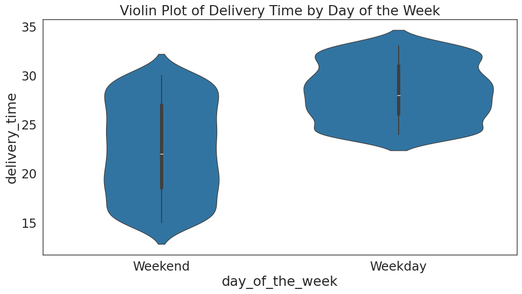

```python
#Create Violin Plots
plt.figure(figsize=(12, 6))
sns.violinplot(x='day_of_the_week', y='delivery_time', data=df)
plt.title("Violin Plot of Delivery Time by Day of the Week")
plt.show()
```

**Question 13: The company wants to provide a promotional offer in the advertisement of the restaurants. The condition to get the offer is that the restaurants must have a rating count of more than 50 and the average rating should be greater than 4. Find the restaurants fulfilling the criteria to get the promotional offer. [3 marks]**

```python
# Convert 'rating' column to numeric, handling 'Not given' values
df['rating'] = pd.to_numeric(df['rating'], errors='coerce')

# Group by restaurant_name and calculate relevant statistics
restaurant_calculations = df.groupby('restaurant_name')['rating'].agg(['count', 'mean'])

# Filter restaurants based on the given criteria
eligible_restaurants = restaurant_stats[(restaurant_calculations['count'] > 50) & (restaurant_calculations['mean'] > 4)]

# Display the list of eligible restaurants
print("Restaurants eligible for promotional offer:")
print(eligible_restaurants)
```

[output not shown]

**Question 14: The company charges the restaurant 25% on the orders having cost greater than 20 dollars and 15% on the orders having cost greater than 5 dollars. Find the net revenue generated by the company across all orders. [3 marks]**

```python
# Calculate the commission for each order
df["commission"] = 0
df.loc[df["cost_of_the_order"] > 20, "commission"] = df["cost_of_the_order"] * 0.25
df.loc[(df["cost_of_the_order"] > 5) & (df["cost_of_the_order"] <= 20), "commission"] = df["cost_of_the_order"] * 0.15

# Calculate the net revenue
net_revenue = df["cost_of_the_order"].sum() - df["commission"].sum()

# Print the result
print(f"Net revenue generated by the company is ${net_revenue}")
```

```
Net revenue generated by the company is $25148.517
```

**Question 15: The company wants to analyze the total time required to deliver the food. What percentage of orders take more than 60 minutes to get delivered from the time the order is placed? (The food has to be prepared and then delivered.) [2 marks]**

```python
# Add a new column named "total_time"
df["total_time"] = df["food_preparation_time"] + df["delivery_time"]

# Count the number of orders where "total_time" is greater than 60
more_than_60 = df[df["total_time"] > 60].shape[0]

# Print the result
print(f"Number of orders with total time greater than 60 minutes: {more_than_60}")
```

```
Number of orders with total time greater than 60 minutes: 200
```

**Question 16: The company wants to analyze the delivery time of the orders on weekdays and weekends. How does the mean delivery time vary during weekdays and weekends? [2 marks]**

```python
#Save days of the week as Weekdays and weekends
weekends = df[df["day_of_the_week"] == "Weekend"]
weekdays = df[df["day_of_the_week"] == "Weekday"]
#Print the mean of the Delivery times on weekends

print("The mean Weekend Delivery time:",
      weekends[['delivery_time']].mean())
print("The mean Weekday Delivery time:",
      weekdays[['delivery_time']].mean())
```

```
The mean Weekend Delivery time: delivery_time    22.470022
dtype: float64
The mean Weekday Delivery time: delivery_time    28.340037
dtype: float64
```

**Question 17: What are your conclusions from the analysis? What recommendations would you like to share to help improve the business? (You can use cuisine type and feedback ratings to drive your business recommendations.) [6 marks]**

**RECOMMENDATIONS:**

1. *Promotional Offer Criteria::*
- Following the Promotional offers mentioned above, find ways to encourage customers to leave more reviews using incentives such as order points.
1. *Analysis of Cuisine Type*
- Consider promoting or featuring cuisines with higher rating.
1. *Customer Engagement:*
- Impliment programs such as a reward-point system, cupons and exclusive membership discounts. This can also be used to encourage customer ratings.
1. *Time Management:*
- Employ technological strategies to streamline and reduce the preparation and delivery time.
1. *Marketing and Pricing:*
- Highlight special promotions, events and discounts to increase orders over the Weekends.
- Review the pricing strategy for the higher cost products and consider reviewing the cost of some popular cuisines.

*Continue to regularly monitor and analyze colleced data.Use the deductions to further improve customer experience and company yield.*